# Exercise 13: Bayesian Optimization

[Optimization in Machine Learning](https://slds-lmu.github.io/website_optimization/)

**Reproducibility**

Produced with Python 3.10 and R 4.4.1. To reproduce, install the pinned package versions below.

**Python**

```bash
pip install numpy==2.0.2 matplotlib==3.10.8 scipy==1.15.3 scikit-learn==1.7.2
```

**R**

```r
install.packages("remotes")
remotes::install_version("ggplot2", "3.5.1")
remotes::install_version("DiceKriging", "1.6.1")
remotes::install_version("patchwork", "1.3.0")
```

## Problem 1: Closed-form Expected Improvement

Derive the closed form expression of the **Expected Improvement** acquisition function:

$$a_{\text{EI}}(\mathbf{x}) = \left(f_{\min}- \hat{f}(\mathbf{x})\right)\, \Phi\!\left(\frac{f_{\min}- \hat{f}(\mathbf{x})}{\hat{s}(\mathbf{x})}\right) + \hat{s}(\mathbf{x})\, \phi\!\left(\frac{f_{\min}- \hat{f}(\mathbf{x})}{\hat{s}(\mathbf{x})}\right).$$

Assume $Y(\mathbf{x}) \sim \mathcal{N}(\hat{f}(\mathbf{x}), \hat{s}^2(\mathbf{x}))$.

*Hints:*

- Start from $a_{\text{EI}}(\mathbf{x}) = \mathbb{E}_y[\max\{f_{\min}- y, 0\}] = \int \max\{f_{\min}- y, 0\}\, p(y)\, dy$.
- Decompose the integral by whether $y < f_{\min}$ or $y \geq f_{\min}$.
- Substitute $u = (y - \hat{f}(\mathbf{x}))/\hat{s}(\mathbf{x})$.
- Use $\int_{-\infty}^z u\,\phi(u)\,du = -\phi(z)$.

**Solution.**

We start with

$$a_{\text{EI}}(\mathbf{x}) = \mathbb{E}_{y}(\max\{f_{\min}- y, 0\}) = \int_{-\infty}^{\infty} \max\{f_{\min}- y, 0\} p(y) dy.$$

Observe that

$$\max\{f_{\min}- y, 0\} =
\begin{cases}
f_{\min}- y, & \text{if } y < f_{\min},\\
0, & \text{otherwise}.
\end{cases}$$

All contributions for $y \ge f_{\min}$ are zero. Therefore, we can additively decompose the integral and it simplifies to

$$a_{\text{EI}}(\mathbf{x}) = \int_{-\infty}^{f_{\min}} \left(f_{\min}- y\right) p(y) dy.$$

$$\begin{aligned}
\alpha_{\text{EI}}(\mathbf{x}) &= \int_{-\infty}^{f_{\min}}\left(f_{\min}-y\right) p(y) dy \\
&= \int_{-\infty}^{f_{\min}}\left(f_{\min}- y\right) \frac{1}{\sqrt{2 \pi \hat{s}(\mathbf{x})^2}} \exp \left(-\frac{\left(y-\hat{f}(\mathbf{x})\right)^2}{2 \hat{s}(\mathbf{x})^2}\right) d y\\
&= \int_{-\infty}^{z}\left(f_{\min}-\hat{f}(\mathbf{x})-u \hat{s}(\mathbf{x})\right) \frac{1}{\sqrt{2 \pi \hat{s}(\mathbf{x})^2}} \exp \left(-\frac{u^2}{2}\right)\hat{s}(\mathbf{x}) d u~\left(\text {Def. } u:=\frac{y-\hat{f}(\mathbf{x})}{\hat{s}(\mathbf{x})}, \frac{d u}{d y}=\frac{1}{\hat{s}(\mathbf{x})}, z := \frac{f_{\min}-\hat{f}(\mathbf{x})}{\hat{s}(\mathbf{x})}\right) \\
&= \int_{-\infty}^{z}\left(f_{\min}-\hat{f}(\mathbf{x})-u \hat{s}(\mathbf{x})\right) \phi(u) d u \\
&= \int_{-\infty}^{z}\left(f_{\min}-\hat{f}(\mathbf{x})\right) \phi(u) d u - \int_{-\infty}^{z}\left(u \hat{s}(\mathbf{x})\right) \phi(u) d u
\end{aligned}$$

Note that

$$\Phi(z)=\int_{-\infty}^{z} \phi(u) d u$$

by definition.

Therefore, regarding the first integral:

$$\int_{-\infty}^{z}\left(f_{\min}-\hat{f}(\mathbf{x})\right) \phi(u) d u = \left(f_{\min}- \hat{f}(\mathbf{x})\right) \Phi(z) = z \hat{s}(\mathbf{x}) \Phi(z).$$

Regarding the second integral we use the identity

$$\int_{-\infty}^z u \phi(u) d u = - \phi(z).$$

Putting both together we obtain:

$$\begin{aligned}
\alpha_{\text{EI}}(\mathbf{x}) &= z \hat{s}(\mathbf{x}) \Phi(z)-\hat{s}(\mathbf{x})(-\phi(z)) \\
&= z \hat{s}(\mathbf{x}) \Phi(z)+\hat{s}(\mathbf{x}) \phi(z)\\
&= \left(f_{\min}- \hat{f}(\mathbf{x})\right) \Phi\left(\frac{f_{\min}- \hat{f}(\mathbf{x})}{\hat{s}(\mathbf{x})}\right) + \hat{s}(\mathbf{x}) \phi\left(\frac{f_{\min}- \hat{f}(\mathbf{x})}{\hat{s}(\mathbf{x})}\right).
\end{aligned}$$

## Problem 2: Implement Bayesian Optimization

Implement BO with a Gaussian-process surrogate and Expected Improvement acquisition. Goal: minimize

$$f: [0, 1] \to \mathbb{R}, \quad x \mapsto 2x\sin(14x).$$

Start with 4 points sampled uniformly at random and terminate after 10 total evaluations.

1. Write the BO loop in pseudocode.
2. Implement it. Optimize the EI via a univariate method (Brent’s / `optimize`).

**Solution.**

Let $\mathcal{D}$ be the initial design consisting of $(x^{[1]}, y^{[1]}), \ldots, (x^{[4]}, y^{[4]})$. Set $t$ to $4$.

While $t < 10$:

1. Fit surrogate model on $\mathcal{D}$.
2. Optimize the Expected Improvement $a_{\text{EI}}(x)$ to obtain a new point $x^{[t+1]} := \operatorname{arg\,max}_{x \in [0, 1]} a_{\text{EI}}(x)$.
3. Evaluate $x^{[t+1]}$ and update design data $\mathcal{D} = \mathcal{D} \cup \{(x^{[t+1]}, f(x^{[t+1]}))\}$.
4. Set $t$ to $t + 1$.

Return $x$ that minimizes $f(x)$ in $\mathcal{D}$: $\operatorname{arg\,min}_{(x, y) \in \mathcal{D}} y$.

**Note**

**R vs. Python.** Both use a Gaussian-kernel GP surrogate with the same closed-form EI, but they draw the 4 initial points from different RNGs (R’s `runif` vs numpy’s), so the specific evaluations - and hence the exact GP posterior and its uncertainty bands - differ between the panels. The method and where BO converges are the same.

**R**

```
BO best after 10 evals: x = 0.7854, f = -1.5708
```

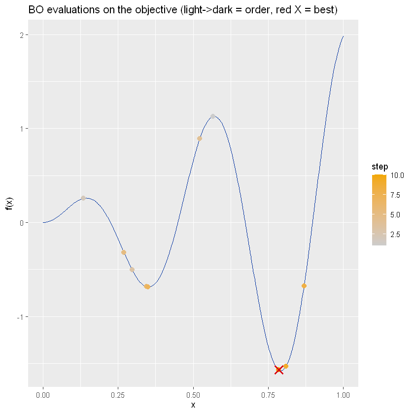

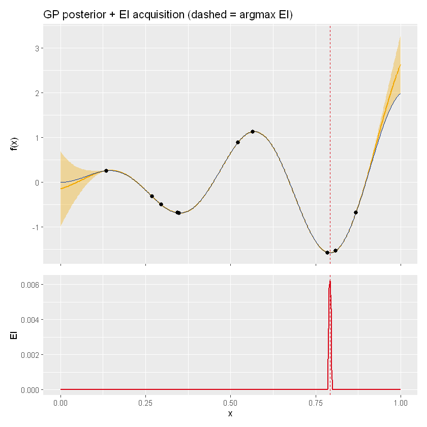

```r
library(DiceKriging)
library(ggplot2)
library(patchwork)

set.seed(308)
f <- function(x) 2 * x * sin(14 * x)                  # objective

# Initial design: 4 random points in [0, 1]
initial_x <- runif(4)
design <- data.frame(x = initial_x, y = f(initial_x))
t <- 4

# Expected improvement using the closed form derived in problem 1.
ei <- function(x, current_fmin, current_gp) {
  pr <- predict(current_gp, newdata = data.frame(x = x), type = "SK")
  diff <- current_fmin - pr$mean
  z <- diff / pr$sd
  diff * pnorm(z) + pr$sd * dnorm(z)
}

while (t < 10) {
  gp <- km(design = design[, 1L, drop = FALSE], response = design[, 2L],
           covtype = "gauss", nugget = 1e-8, control = list(trace = FALSE))
  fmin <- min(design$y)
  x_new <- optimize(ei, interval = c(0, 1), maximum = TRUE,
                    current_fmin = fmin, current_gp = gp)$maximum
  design <- rbind(design, data.frame(x = x_new, y = f(x_new)))
  t <- t + 1
}

bo_best <- design[which.min(design$y), ]
cat(sprintf("BO best after 10 evals: x = %.4f, f = %+.4f\n",
            bo_best$x, bo_best$y))

# Objective with BO's evaluations (light -> dark = evaluation order)
x_grid <- seq(0, 1, length.out = 401)
df_curve <- data.frame(x = x_grid, y = f(x_grid))
df_design <- design
df_design$step <- seq_len(nrow(df_design))

ggplot() +
  geom_line(data = df_curve, aes(x, y), color = "#0033A0", linewidth = 0.5) +
  geom_point(data = df_design, aes(x, y, color = step), size = 2.4) +
  geom_point(data = bo_best, aes(x, y), color = "#D90012",
             size = 3.5, shape = 4, stroke = 1.5) +
  scale_color_gradient(low = "grey80", high = "#F2A800") +
  ylab("f(x)") +
  ggtitle("BO evaluations on the objective (light->dark = order, red X = best)")

# GP posterior at the final BO iteration (mean +/- 2*sd over the grid)
final_gp <- km(design = design[, 1L, drop = FALSE], response = design[, 2L],
               covtype = "gauss", nugget = 1e-8, control = list(trace = FALSE))
pred <- predict(final_gp, newdata = data.frame(x = x_grid), type = "SK")
df_post <- data.frame(x = x_grid, mean = pred$mean,
                      lo = pred$mean - 2 * pred$sd,
                      hi = pred$mean + 2 * pred$sd)

# Expected improvement induced by that surrogate;
# BO would query its argmax next.
ei_grid <- ei(x_grid, min(design$y), final_gp)
x_ei_next <- x_grid[which.max(ei_grid)]
df_ei <- data.frame(x = x_grid, ei = ei_grid)

p_post <- ggplot() +
  geom_ribbon(data = df_post, aes(x, ymin = lo, ymax = hi),
              fill = "#F2A800", alpha = 0.35) +
  geom_line(data = df_post, aes(x, mean), color = "#F2A800", linewidth = 0.7) +
  geom_line(data = df_curve, aes(x, y), color = "#0033A0", linewidth = 0.5) +
  geom_point(data = design, aes(x, y), color = "black", size = 1.8) +
  geom_vline(xintercept = x_ei_next, linetype = "dashed",
             color = "#D90012", linewidth = 0.5) +
  ylab("f(x)") +
  ggtitle("GP posterior + EI acquisition (dashed = argmax EI)") +
  theme(axis.title.x = element_blank(), axis.text.x = element_blank())

p_ei <- ggplot(df_ei, aes(x, ei)) +
  geom_line(color = "#D90012", linewidth = 0.6) +
  geom_vline(xintercept = x_ei_next, linetype = "dashed",
             color = "#D90012", linewidth = 0.5) +
  ylab("EI") + xlab("x")

print((p_post / p_ei) + plot_layout(heights = c(2, 1)))
```

**Python**

```
BO best after 10 evals: x = 0.7898, f = -1.5766
```

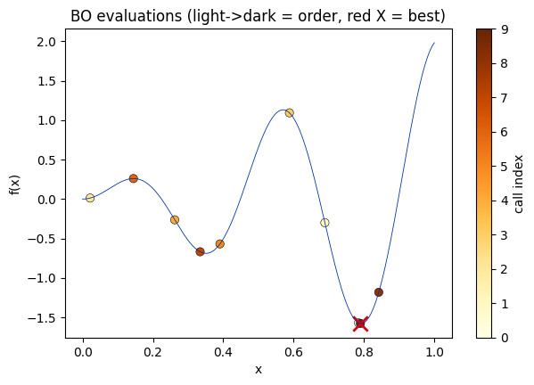

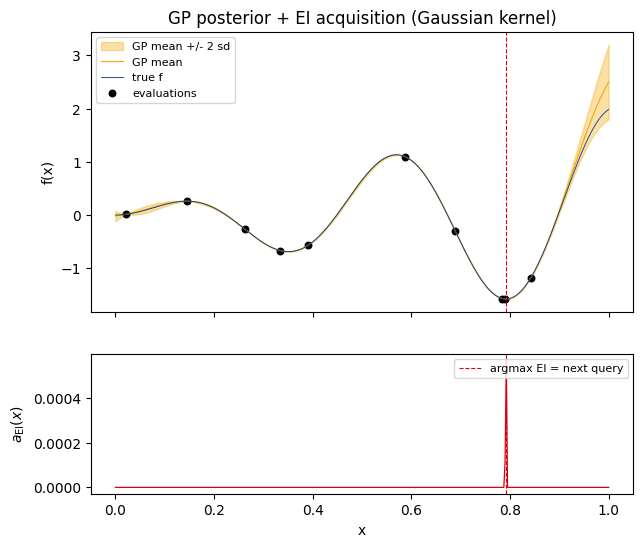

```python
import numpy as np
import matplotlib.pyplot as plt
from scipy.stats import norm
from scipy.optimize import minimize_scalar
from sklearn.gaussian_process import GaussianProcessRegressor
from sklearn.gaussian_process.kernels import ConstantKernel, RBF


def f(x):
    """Objective: 2x sin(14x) on [0, 1]."""
    return 2 * x * np.sin(14 * x)


# Gaussian-kernel GP surrogate, matching R's DiceKriging covtype = "gauss".
kernel = ConstantKernel(1.0) * RBF(length_scale=0.1)


def fit_gp(xd, yd):
    gp = GaussianProcessRegressor(kernel=kernel, alpha=1e-8, normalize_y=True)
    gp.fit(xd[:, None], yd)
    return gp


# Expected improvement using the closed form derived in problem 1.
def ei(x, current_fmin, gp):
    mu, sd = gp.predict(np.array([[x]]), return_std=True)
    mu, sd = mu[0], max(sd[0], 1e-9)
    diff = current_fmin - mu
    z = diff / sd
    return diff * norm.cdf(z) + sd * norm.pdf(z)


# Initial design: 4 random points in [0, 1]
np.random.seed(308)
x_design = np.random.uniform(size=4)
y_design = f(x_design)
t = 4

while t < 10:
    gp = fit_gp(x_design, y_design)
    fmin = y_design.min()
    res = minimize_scalar(lambda x: -ei(x, fmin, gp),
                          bounds=(0, 1), method="bounded")
    x_design = np.append(x_design, res.x)
    y_design = np.append(y_design, f(res.x))
    t += 1

best = int(np.argmin(y_design))
print(f"BO best after 10 evals: x = {x_design[best]:.4f}, "
      f"f = {y_design[best]:+.4f}")

# Objective with BO's evaluations (light -> dark = evaluation order)
x_grid = np.linspace(0, 1, 401)
fig, ax = plt.subplots(figsize=(7, 4.5))
ax.plot(x_grid, f(x_grid), color="#0033A0", linewidth=0.6)
sc = ax.scatter(x_design, y_design, c=np.arange(len(x_design)), cmap="YlOrBr",
                s=45, edgecolor="k", linewidth=0.4)
ax.scatter(x_design[best], y_design[best], color="#D90012", marker="x",
           s=140, linewidths=2)
ax.set_xlabel("x"); ax.set_ylabel("f(x)")
fig.colorbar(sc, ax=ax, label="call index")
ax.set_title("BO evaluations (light->dark = order, red X = best)")
plt.show()

# GP posterior at the final iteration (mean +/- 2*sd over the grid)
final_gp = fit_gp(x_design, y_design)
mu, sd = final_gp.predict(x_grid[:, None], return_std=True)

# EI induced by that surrogate; BO would query its argmax next.
fmin = y_design.min()
sd_safe = np.maximum(sd, 1e-9)
z = (fmin - mu) / sd_safe
ei_grid = (fmin - mu) * norm.cdf(z) + sd_safe * norm.pdf(z)
x_ei_next = x_grid[int(np.argmax(ei_grid))]

fig, (ax1, ax2) = plt.subplots(2, 1, figsize=(7, 6), sharex=True,
                               gridspec_kw={"height_ratios": [2, 1]})
ax1.fill_between(x_grid, mu - 2 * sd, mu + 2 * sd, color="#F2A800", alpha=0.35,
                 label="GP mean +/- 2 sd")
ax1.plot(x_grid, mu, color="#F2A800", linewidth=0.8, label="GP mean")
ax1.plot(x_grid, f(x_grid), color="#0033A0", linewidth=0.6, label="true f")
ax1.scatter(x_design, y_design, color="black", s=22, label="evaluations")
ax1.axvline(x_ei_next, linestyle="--", color="#D90012", linewidth=0.8)
ax1.set_ylabel("f(x)"); ax1.legend(loc="upper left", fontsize=8)
ax1.set_title("GP posterior + EI acquisition (Gaussian kernel)")
ax2.plot(x_grid, ei_grid, color="#D90012", linewidth=0.9)
ax2.axvline(x_ei_next, linestyle="--", color="#D90012", linewidth=0.8,
            label="argmax EI = next query")
ax2.set_xlabel("x"); ax2.set_ylabel(r"$a_{\mathrm{EI}}(x)$")
ax2.legend(loc="upper right", fontsize=8)
plt.show()
```